# STAT 408 Final Project

### Predictive Model Preparation

Since one of the goals of our project is the predict the number of bikes needed for a given day based on provided conditions, it would be best to adjust the categorical variables by turning them into dummy variables/one-hot encoding them.

```r
# Creating Dummy Variables
bike_sharing <- fastDummies::dummy_cols(bike_sharing, remove_first_dummy = TRUE)

# Removing the original columns
bike_sharing <- bike_sharing[ ,!names(bike_sharing) %in% c("season", "year", "month", "holiday", "weekday", "workingday", "weathersit")]
head(bike_sharing)
```

```
##       temp    atemp      hum windspeed  cnt season_Summer season_Fall
## 1 0.344167 0.363625 0.805833 0.1604460  985             0           0
## 2 0.363478 0.353739 0.696087 0.2485390  801             0           0
## 3 0.196364 0.189405 0.437273 0.2483090 1349             0           0
## 4 0.200000 0.212122 0.590435 0.1602960 1562             0           0
## 5 0.226957 0.229270 0.436957 0.1869000 1600             0           0
## 6 0.204348 0.233209 0.518261 0.0895652 1606             0           0
##   season_Winter year_2012 month_February month_March month_April month_May
## 1             0         0              0           0           0         0
## 2             0         0              0           0           0         0
## 3             0         0              0           0           0         0
## 4             0         0              0           0           0         0
## 5             0         0              0           0           0         0
## 6             0         0              0           0           0         0
##   month_June month_July month_August month_September month_October
```

[output cut: 27 more lines]

We then split the resulting dataset into training and testing datasets, using an 80:20 split.

```r
sample_size = floor(0.8 * nrow(bike_sharing))
indices = sample(seq_len(nrow(bike_sharing)), size = sample_size)
bike_sharing_trn = bike_sharing[indices,]
bike_sharing_tst = bike_sharing[-indices,]

adj_r_squared <- c()
max_vif <- c()
```

### Models

#### Base Model

This is the initial model similar to the one show above that to used a base comparison for the other models.

```r
model0 <- lm(cnt ~ .-workingday_Yes, data = bike_sharing_trn)
```

#### Model 1: AIC

```r
model1 <- lm(cnt ~ . -workingday_Yes, data = bike_sharing_trn)
step(model1)
```

```
## Start:  AIC=7779.3
## cnt ~ (temp + atemp + hum + windspeed + season_Summer + season_Fall +
##     season_Winter + year_2012 + month_February + month_March +
##     month_April + month_May + month_June + month_July + month_August +
##     month_September + month_October + month_November + month_December +
##     holiday_Yes + weekday_Monday + weekday_Tuesday + weekday_Wednesday +
##     weekday_Thursday + weekday_Friday + weekday_Saturday + workingday_Yes +
##     weathersit_Misty + `weathersit_Snow/Rain`) - workingday_Yes
##
##                          Df Sum of Sq       RSS    AIC
## - month_August            1     45717 322445197 7777.4
## - month_February          1     75925 322475406 7777.4
## - month_November          1    264158 322663638 7777.8
## - month_December          1    352928 322752409 7777.9
## - atemp                   1    365080 322764561 7778.0
## - month_July              1    403021 322802502 7778.0
## - month_June              1    753983 323153464 7778.7
## <none>                                322399481 7779.3
## - month_October           1   1162450 323561931 7779.4
## - month_April             1   1795749 324195230 7780.5
## - weekday_Monday          1   3068421 325467902 7782.8
## - temp                    1   3277471 325676951 7783.2
## - weekday_Tuesday         1   3451614 325851095 7783.5
## - month_September         1   4129817 326529298 7784.7
## - month_May               1   4215307 326614788 7784.9
## - month_March             1   4324608 326724089 7785.1
## - holiday_Yes             1   4810261 327209741 7785.9
## - weekday_Thursday        1   5007605 327407085 7786.3
## - weekday_Wednesday       1   5386195 327785676 7787.0
## - weekday_Friday          1   5840089 328239570 7787.8
## - season_Summer           1   9559033 331958513 7794.4
## - weekday_Saturday        1  10412594 332812074 7795.9
## - season_Fall             1  11395242 333794723 7797.6
## - hum                     1  16212091 338611572 7806.0
## - weathersit_Misty        1  18490478 340889959 7809.9
## - windspeed               1  24026121 346425602 7819.3
## - season_Winter           1  34323880 356723360 7836.4
## - `weathersit_Snow/Rain`  1  49251419 371650900 7860.3
## - year_2012               1 577765198 900164678 8376.9
##
```

[output cut: 164 more lines]

```
## - weekday_Friday          1   5649704 329286915 7779.6
## - month_May               1   6898194 330535405 7781.9
## - month_March             1   6938840 330576051 7781.9
## - month_October           1   8182481 331819692 7784.1
## - weekday_Saturday        1  10542293 334179504 7788.3
## - season_Summer           1  11027482 334664693 7789.1
## - hum                     1  17577968 341215179 7800.4
## - weathersit_Misty        1  18187713 341824924 7801.5
## - season_Fall             1  20914621 344551832 7806.1
## - month_September         1  21174918 344812129 7806.5
## - windspeed               1  26883185 350520396 7816.1
## - `weathersit_Snow/Rain`  1  49827580 373464791 7853.2
## - season_Winter           1  87673977 411311188 7909.5
## - temp                    1  92892953 416530164 7916.9
## - year_2012               1 579761215 903398426 8369.0
```

```
##
## Call:
## lm(formula = cnt ~ temp + hum + windspeed + season_Summer + season_Fall +
##     season_Winter + year_2012 + month_March + month_April + month_May +
##     month_June + month_July + month_September + month_October +
##     holiday_Yes + weekday_Monday + weekday_Tuesday + weekday_Wednesday +
##     weekday_Thursday + weekday_Friday + weekday_Saturday + weathersit_Misty +
##     `weathersit_Snow/Rain`, data = bike_sharing_trn)
##
## Coefficients:
##            (Intercept)                    temp                     hum
##                 1701.5                  4749.6                 -1750.0
##              windspeed           season_Summer             season_Fall
##                -3071.7                   793.1                  1033.3
##          season_Winter               year_2012             month_March
##                 1431.4                  2034.9                   479.0
##            month_April               month_May              month_June
##                  467.5                   738.3                   289.8
##             month_July         month_September           month_October
##                 -356.2                   786.5                   518.2
##            holiday_Yes          weekday_Monday         weekday_Tuesday
##                 -636.2                   295.3                   290.2
##      weekday_Wednesday        weekday_Thursday          weekday_Friday
##                  359.6                   349.2                   372.5
##       weekday_Saturday        weathersit_Misty  `weathersit_Snow/Rain`
##                  500.2                  -477.9                 -1960.0
```

```r
model1 <- lm(formula = cnt ~ temp + hum + windspeed + season_Summer + season_Fall +
    season_Winter + year_2012 + month_March + month_April + month_May +
    month_June + month_July + month_September + month_October +
    holiday_Yes + weekday_Monday + weekday_Tuesday + weekday_Wednesday +
    weekday_Thursday + weekday_Friday + weekday_Saturday + weathersit_Misty +
    `weathersit_Snow/Rain`, data = bike_sharing_trn)
summary(model1)
```

```
##
## Call:
## lm(formula = cnt ~ temp + hum + windspeed + season_Summer + season_Fall +
##     season_Winter + year_2012 + month_March + month_April + month_May +
##     month_June + month_July + month_September + month_October +
##     holiday_Yes + weekday_Monday + weekday_Tuesday + weekday_Wednesday +
##     weekday_Thursday + weekday_Friday + weekday_Saturday + weathersit_Misty +
##     `weathersit_Snow/Rain`, data = bike_sharing_trn)
##
## Residuals:
##     Min      1Q  Median      3Q     Max
## -3814.7  -364.0    87.6   444.8  2819.0
##
## Coefficients:
##                        Estimate Std. Error t value Pr(>|t|)
## (Intercept)             1701.47     256.10   6.644 7.26e-11 ***
## temp                    4749.56     374.63  12.678  < 2e-16 ***
## hum                    -1750.02     317.32  -5.515 5.33e-08 ***
## windspeed              -3071.66     450.37  -6.820 2.36e-11 ***
## season_Summer            793.07     181.55   4.368 1.49e-05 ***
## season_Fall             1033.30     171.77   6.016 3.24e-09 ***
## season_Winter           1431.39     116.21  12.317  < 2e-16 ***
## year_2012               2034.93      64.25  31.673  < 2e-16 ***
## month_March              479.04     138.25   3.465 0.000571 ***
## month_April              467.47     212.44   2.200 0.028183 *
## month_May                738.25     213.68   3.455 0.000592 ***
## month_June               289.79     189.35   1.530 0.126477
## month_July              -356.25     149.41  -2.384 0.017444 *
## month_September          786.46     129.93   6.053 2.60e-09 ***
## month_October            518.24     137.73   3.763 0.000186 ***
## holiday_Yes             -636.17     204.51  -3.111 0.001962 **
## weekday_Monday           295.26     126.00   2.343 0.019458 *
## weekday_Tuesday          290.19     118.24   2.454 0.014421 *
## weekday_Wednesday        359.63     118.35   3.039 0.002487 **
## weekday_Thursday         349.24     119.46   2.924 0.003601 **
## weekday_Friday           372.52     119.14   3.127 0.001860 **
## weekday_Saturday         500.18     117.11   4.271 2.29e-05 ***
## weathersit_Misty        -477.94      85.20  -5.610 3.19e-08 ***
## `weathersit_Snow/Rain` -1959.99     211.08  -9.285  < 2e-16 ***
## ---
## Signif. codes:  0 '***' 0.001 '**' 0.01 '*' 0.05 '.' 0.1 ' ' 1
##
## Residual standard error: 760.2 on 560 degrees of freedom
## Multiple R-squared:  0.8485, Adjusted R-squared:  0.8423
## F-statistic: 136.4 on 23 and 560 DF,  p-value: < 2.2e-16
```

#### Model 2: Transformation

```r
#sathvik Model_2
bike_sharing_trn_transformed <- bike_sharing_trn
bike_sharing_tst_transformed <- bike_sharing_tst

# Transformation
bike_sharing_trn_transformed$log_temp <- log(bike_sharing_trn_transformed$temp)
bike_sharing_trn_transformed$log_hum <- log(bike_sharing_trn_transformed$hum)
bike_sharing_trn_transformed$log_windspeed <- log(bike_sharing_trn_transformed$windspeed)
bike_sharing_trn_transformed$log_cnt <- log(bike_sharing_trn_transformed$cnt + 1)

# Doing same for the test set
bike_sharing_tst_transformed$log_temp <- log(bike_sharing_tst_transformed$temp)
bike_sharing_tst_transformed$log_hum <- log(bike_sharing_tst_transformed$hum)
bike_sharing_tst_transformed$log_windspeed <- log(bike_sharing_tst_transformed$windspeed)


# Transformation for the response variable (cnt)
bike_sharing_tst_transformed$log_cnt <- log(bike_sharing_tst_transformed$cnt + 1)

#model with the transformed response variable
model2 <- lm(formula = log_cnt ~ log_temp + log(1 + hum) + log_windspeed + season_Summer + season_Fall + season_Winter + year_2012 + month_February + month_March + month_April + month_May + month_June + month_July + month_August + month_September + month_October + month_November + month_December + holiday_Yes + weekday_Monday + weekday_Tuesday + weekday_Wednesday + weekday_Thursday + weekday_Friday + weekday_Saturday + weathersit_Misty + `weathersit_Snow/Rain`, data = bike_sharing_trn_transformed)
summary(model2)
```

```
##
## Call:
## lm(formula = log_cnt ~ log_temp + log(1 + hum) + log_windspeed +
##     season_Summer + season_Fall + season_Winter + year_2012 +
##     month_February + month_March + month_April + month_May +
##     month_June + month_July + month_August + month_September +
##     month_October + month_November + month_December + holiday_Yes +
##     weekday_Monday + weekday_Tuesday + weekday_Wednesday + weekday_Thursday +
##     weekday_Friday + weekday_Saturday + weathersit_Misty + `weathersit_Snow/Rain`,
##     data = bike_sharing_trn_transformed)
##
## Residuals:
##     Min      1Q  Median      3Q     Max
## -4.2358 -0.0860  0.0277  0.1270  0.9224
##
## Coefficients:
##                        Estimate Std. Error t value Pr(>|t|)
## (Intercept)             8.44642    0.15161  55.713  < 2e-16 ***
## log_temp                0.66686    0.06340  10.518  < 2e-16 ***
## log(1 + hum)           -0.79031    0.19268  -4.102 4.72e-05 ***
## log_windspeed          -0.15972    0.03048  -5.240 2.28e-07 ***
## season_Summer           0.24688    0.07518   3.284 0.001089 **
## season_Fall             0.39490    0.09066   4.356 1.58e-05 ***
## season_Winter           0.53907    0.07886   6.836 2.15e-11 ***
## year_2012               0.45215    0.02468  18.323  < 2e-16 ***
## month_February          0.04392    0.06230   0.705 0.481105
## month_March             0.05749    0.07164   0.802 0.422650
## month_April             0.02650    0.10601   0.250 0.802722
## month_May               0.11220    0.10990   1.021 0.307743
## month_June             -0.03887    0.11419  -0.340 0.733705
## month_July             -0.23107    0.12675  -1.823 0.068826 .
## month_August           -0.18595    0.12370  -1.503 0.133357
## month_September        -0.01581    0.11165  -0.142 0.887445
## month_October          -0.17327    0.10423  -1.662 0.096993 .
## month_November         -0.11567    0.10087  -1.147 0.251991
## month_December         -0.11919    0.08051  -1.480 0.139317
## holiday_Yes            -0.17924    0.07884  -2.273 0.023379 *
## weekday_Monday          0.05433    0.04816   1.128 0.259808
## weekday_Tuesday         0.07759    0.04532   1.712 0.087430 .
## weekday_Wednesday       0.08519    0.04531   1.880 0.060618 .
## weekday_Thursday        0.09754    0.04581   2.129 0.033659 *
## weekday_Friday          0.10484    0.04551   2.304 0.021603 *
## weekday_Saturday        0.11572    0.04475   2.586 0.009971 **
## weathersit_Misty       -0.11629    0.03220  -3.612 0.000331 ***
## `weathersit_Snow/Rain` -1.06505    0.07876 -13.522  < 2e-16 ***
## ---
## Signif. codes:  0 '***' 0.001 '**' 0.01 '*' 0.05 '.' 0.1 ' ' 1
##
## Residual standard error: 0.2903 on 556 degrees of freedom
## Multiple R-squared:  0.7624, Adjusted R-squared:  0.7509
## F-statistic: 66.09 on 27 and 556 DF,  p-value: < 2.2e-16
```

```r
x.test <- bike_sharing_tst_transformed[, -c(5)]

# Make predictions
yhat.t <- predict(model2, x.test)
y.t <- bike_sharing_tst_transformed$log_cnt
MSE.t <- mean((y.t - yhat.t)^2)
MSE.t
```

```
## [1] 0.06926982
```

```r
RMSE.t <- sqrt(MSE.t)
RMSE.t
```

```
## [1] 0.2631916
```

```r
NRMSE.t <- RMSE.t / mean(y.t)
NRMSE.t
```

```
## [1] 0.03191688
```

#### Model 3: Correlation Matrix

```r
# Compute correlation matrix
correlation_matrix <- cor(bike_sharing_trn)

# Identifying pairs of variables with high correlation coefficients
highly_correlated_pairs <- which(correlation_matrix > 0.8 & correlation_matrix < 1, arr.ind = TRUE)
print(highly_correlated_pairs)
```

```
##       row col
## atemp   2   1
## temp    1   2
```

```r
bike_sharing_trn_corr <- bike_sharing_trn
bike_sharing_trn_corr <- subset(bike_sharing_trn_corr, select = -c(atemp)) # excluded "atemp"

bike_sharing_tst_corr <- bike_sharing_tst
bike_sharing_tst_corr <- subset(bike_sharing_tst_corr, select = -c(atemp))

#model without atemp
model3 <- lm(cnt ~ . -workingday_Yes, data = bike_sharing_trn_corr)
summary(model3)
```

```
##
## Call:
## lm(formula = cnt ~ . - workingday_Yes, data = bike_sharing_trn_corr)
##
## Residuals:
##     Min      1Q  Median      3Q     Max
## -3842.2  -354.0    88.5   443.0  2841.3
##
## Coefficients:
##                        Estimate Std. Error t value Pr(>|t|)
## (Intercept)             1703.38     268.46   6.345 4.61e-10 ***
## temp                    4599.16     460.97   9.977  < 2e-16 ***
## hum                    -1699.37     322.45  -5.270 1.95e-07 ***
## windspeed              -3033.74     453.01  -6.697 5.22e-11 ***
## season_Summer            803.13     197.30   4.071 5.37e-05 ***
## season_Fall             1062.03     238.52   4.453 1.03e-05 ***
## season_Winter           1593.33     206.81   7.704 6.08e-14 ***
## year_2012               2039.18      64.65  31.541  < 2e-16 ***
## month_February            62.48     161.30   0.387  0.69866
## month_March              496.31     181.13   2.740  0.00634 **
## month_April              486.34     272.93   1.782  0.07530 .
## month_May                774.13     289.61   2.673  0.00774 **
## month_June               338.35     310.84   1.088  0.27685
## month_July              -311.90     349.74  -0.892  0.37289
## month_August              60.76     334.93   0.181  0.85611
## month_September          770.24     294.09   2.619  0.00906 **
## month_October            384.27     270.08   1.423  0.15536
## month_November          -171.25     261.46  -0.655  0.51276
## month_December          -159.57     208.86  -0.764  0.44519
## holiday_Yes             -608.52     207.00  -2.940  0.00342 **
## weekday_Monday           293.98     126.44   2.325  0.02043 *
## weekday_Tuesday          291.30     118.95   2.449  0.01463 *
## weekday_Wednesday        360.66     118.99   3.031  0.00255 **
## weekday_Thursday         352.20     120.32   2.927  0.00356 **
## weekday_Friday           374.12     119.48   3.131  0.00183 **
## weekday_Saturday         499.01     117.46   4.248 2.53e-05 ***
## weathersit_Misty        -487.66      86.18  -5.659 2.45e-08 ***
## `weathersit_Snow/Rain` -1961.24     211.97  -9.253  < 2e-16 ***
## ---
## Signif. codes:  0 '***' 0.001 '**' 0.01 '*' 0.05 '.' 0.1 ' ' 1
##
## Residual standard error: 761.9 on 556 degrees of freedom
## Multiple R-squared:  0.8489, Adjusted R-squared:  0.8416
## F-statistic: 115.7 on 27 and 556 DF,  p-value: < 2.2e-16
```

#### Model 4: KNN

```r
# knn model
factors <- colnames(bike_sharing_trn)[-c(2,5,10,16,19,20,28)]
model4 <- knnreg(bike_sharing_trn[,factors], bike_sharing_trn$cnt, k=9)

# Predict on the TRAIN set and calculate test scores
yhat.train = predict(model4, bike_sharing_trn[,factors])

y.train <- bike_sharing_trn$cnt
MSE.train <- mean((y.train - yhat.train)^2)
MSE.train
```

```
## [1] 815461.3
```

```r
RMSE.train <- sqrt(MSE.train)
RMSE.train
```

```
## [1] 903.0289
```

```r
NRMSE.train <- RMSE.train / mean(y.train)
NRMSE.train
```

```
## [1] 0.1992266
```

```r
# Predict on the TEST set and calculate test scores
yhat.test = predict(model4, bike_sharing_tst[,factors])

y.test <- bike_sharing_tst$cnt
MSE.test <- mean((y.test - yhat.test)^2)
MSE.test
```

```
## [1] 969013.5
```

```r
RMSE.test <- sqrt(MSE.test)
RMSE.test
```

```
## [1] 984.3849
```

```r
NRMSE.test <- RMSE.test / mean(y.test)
NRMSE.test
```

```
## [1] 0.2241404
```

#### Model 5: Ridge Regression

```r
library(glmnet)
# Assuming you have a dataframe 'data' with predictors and a response variable 'y'
x <- as.matrix(bike_sharing_trn[, -5])  # predictor variables
y <- bike_sharing_trn$cnt  # response variable

# Scaling the predictor variables
x <- scale(x)

# Fit ridge regression model
# Alpha = 0 indicates ridge regression
ridge_model <- glmnet(x, y, alpha = 0)

# To view the coefficients at different values of lambda
print(coef(ridge_model))
```

```
## 30 x 100 sparse Matrix of class "dgCMatrix"
```

```
##   [[ suppressing 100 column names 's0', 's1', 's2' ... ]]
```

[output not shown]

[output cut: 720 more lines]

```
## month_August           74.388463   74.736482   75.022727   75.240416
## month_September       257.101135  258.658897  260.011053  261.163264
## month_October         160.337428  159.984885  159.498192  158.884803
## month_November         20.365221   18.942548   17.411457   15.780999
## month_December        -17.968064  -17.628488  -17.414650  -17.322403
## holiday_Yes           -60.929526  -60.711194  -60.472556  -60.217804
## weekday_Monday          3.630015    4.105663    4.553816    4.974901
## weekday_Tuesday         2.612750    3.182456    3.725189    4.240651
## weekday_Wednesday      29.358997   29.962671   30.530849   31.064239
## weekday_Thursday       33.254825   33.317035   33.375111   33.428996
## weekday_Friday         39.847412   40.058018   40.259253   40.451244
## weekday_Saturday      147.099858  149.509353  151.763537  153.867574
## workingday_Yes        103.597034  104.992437  106.302785  107.530045
## weathersit_Misty     -215.682550 -216.665159 -217.594941 -218.475970
## weathersit_Snow/Rain -316.357140 -317.966344 -319.465699 -320.862776
```

```r
# Cross-validation to find optimal lambda
cv_ridge <- cv.glmnet(x, y, alpha = 0)

# Best lambda
best_lambda <- cv_ridge$lambda.min
print(best_lambda)
```

```
## [1] 117.9615
```

```r
# Fit model using the best lambda
final_ridge_model <- glmnet(x, y, alpha = 0, lambda = best_lambda)

# Set test predictor
x.test <- as.matrix(bike_sharing_tst[, -5])  # New predictor variables
x.test <- scale(x.test)  # Don't forget to scale the new predictor variables

# Make predictions
yhat.ridge <- predict(final_ridge_model, x.test)
y.ridge <- bike_sharing_tst$cnt
MSE.ridge <- mean((y.ridge - yhat.ridge)^2)
MSE.ridge
```

```
## [1] 713892.1
```

```r
RMSE.ridge <- sqrt(MSE.ridge)
RMSE.ridge
```

```
## [1] 844.9213
```

```r
NRMSE.ridge <- RMSE.ridge / mean(y.ridge)
NRMSE.ridge
```

```
## [1] 0.1923851
```

#### Model 6: Transformation + Ridge Regression

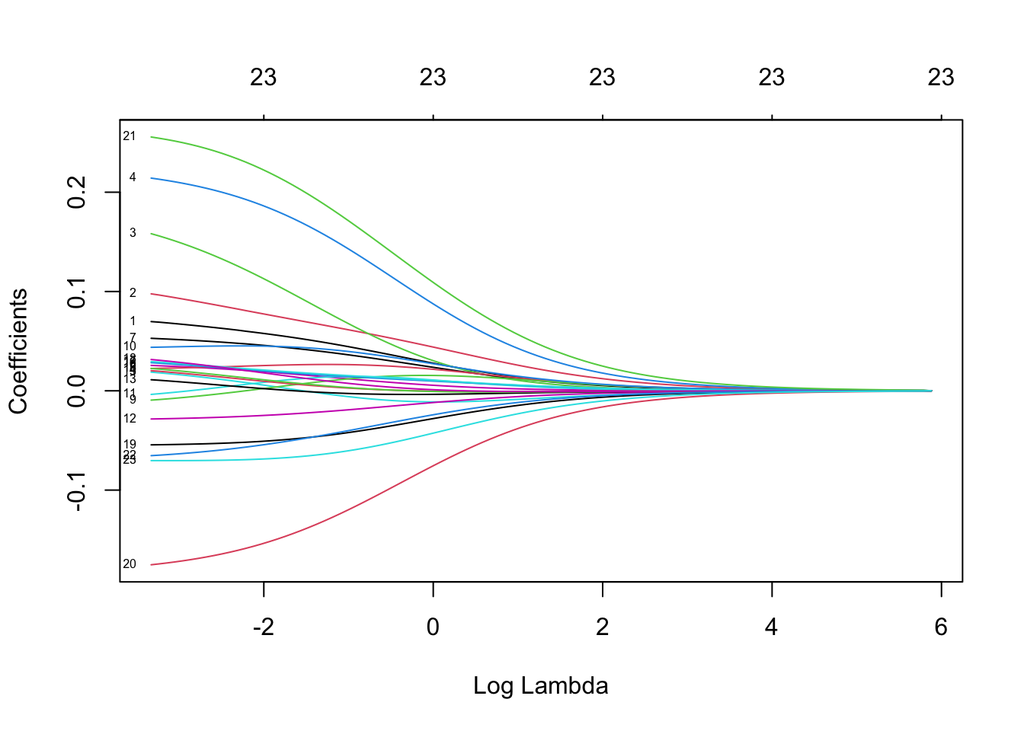

```r
bs_train_t <- bike_sharing_trn
bs_test_t <- bike_sharing_tst

# Transformation
bs_train_t$cnt.t <- log(bs_train_t$cnt + 1)
bs_test_t$cnt.t <- log(bs_test_t$cnt + 1)

# Transformation
bs_train_t$log_temp <- log(bs_train_t$temp)
bs_train_t$log_hum <- log(bs_train_t$hum+1)
bs_train_t$log_windspeed <- log(bs_train_t$windspeed)

# Doing same for the test set
bs_test_t$log_temp <- log(bs_test_t$temp)
bs_test_t$log_hum <- log(bs_test_t$hum+1)
bs_test_t$log_windspeed <- log(bs_test_t$windspeed)

# Assuming you have a dataframe 'data' with predictors and a response variable 'y'
x <- as.matrix(bs_train_t[, -c(1,2,3,4,5,10,16,19,20,28,31)])  # predictor variables
y <- bs_train_t$cnt.t  # response variable

# Scaling the predictor variables
x <- scale(x)

# Fit ridge regression model
# Alpha = 0 indicates ridge regression
ridge_model <- glmnet(x, y, alpha = 0)

# Plotting coefficient paths
plot(ridge_model, xvar = "lambda", label = TRUE)
```

```r
# To view the coefficients at different values of lambda
print(coef(ridge_model))
```

```
## 24 x 100 sparse Matrix of class "dgCMatrix"
```

```
##   [[ suppressing 100 column names 's0', 's1', 's2' ... ]]
```

[output not shown]

[output cut: 570 more lines]

```
## month_July           -0.007518331 -0.008186946 -0.008818810 -0.009384984
## month_September       0.044313087  0.044139227  0.043962617  0.043806676
## month_October        -0.001476809 -0.002228577 -0.002943255 -0.003623311
## holiday_Yes          -0.027920912 -0.028087384 -0.028240528 -0.028378039
## weekday_Monday        0.009447461  0.010042712  0.010619070  0.011145182
## weekday_Tuesday       0.018297616  0.018983955  0.019646336  0.020254329
## weekday_Wednesday     0.020432118  0.021154577  0.021850053  0.022491244
## weekday_Thursday      0.026726519  0.027284106  0.027824252  0.028324773
## weekday_Friday        0.027782532  0.028343892  0.028888498  0.029394133
## weekday_Saturday      0.029160332  0.029986429  0.030777561  0.031514175
## weathersit_Misty     -0.054055899 -0.054190974 -0.054311549 -0.054429062
## weathersit_Snow/Rain -0.172356234 -0.173381022 -0.174327497 -0.175204324
## log_temp              0.251542575  0.253026287  0.254367811  0.255617102
## log_hum              -0.063760730 -0.064318905 -0.064837476 -0.065309132
## log_windspeed        -0.070309130 -0.070313643 -0.070308007 -0.070298212
```

```r
# Cross-validation to find optimal lambda
cv_ridge <- cv.glmnet(x, y, alpha = 0)

# Best lambda
best_lambda <- cv_ridge$lambda.min
print(best_lambda)
```

```
## [1] 0.03579085
```

```r
# Fit model using the best lambda
final_ridge_model <- glmnet(x, y, alpha = 0, lambda = best_lambda)

# Set test predictor
x.test <- as.matrix(bs_test_t[, -c(1,2,3,4,5,10,16,19,20,28,31)])  # New predictor variables
x.test <- scale(x.test)  # Don't forget to scale the new predictor variables

# Make predictions
yhat.trr <- predict(final_ridge_model, x.test)
y.trr <- bs_test_t$cnt.t
MSE.trr <- mean((y.trr - yhat.trr)^2)
MSE.trr
```

```
## [1] 0.08340638
```

```r
RMSE.trr <- sqrt(MSE.trr)
RMSE.trr
```

```
## [1] 0.2888016
```

```r
NRMSE.trr <- RMSE.trr / mean(y.trr)
NRMSE.trr
```

```
## [1] 0.03502257
```

## Results

### Plot Diagnostics

#### Base Model

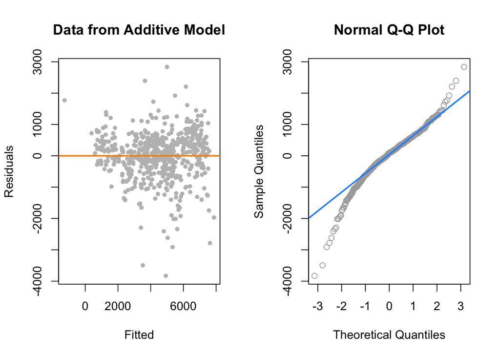

```r
plot_diagnostics(model0)
```

#### Model 1: AIC

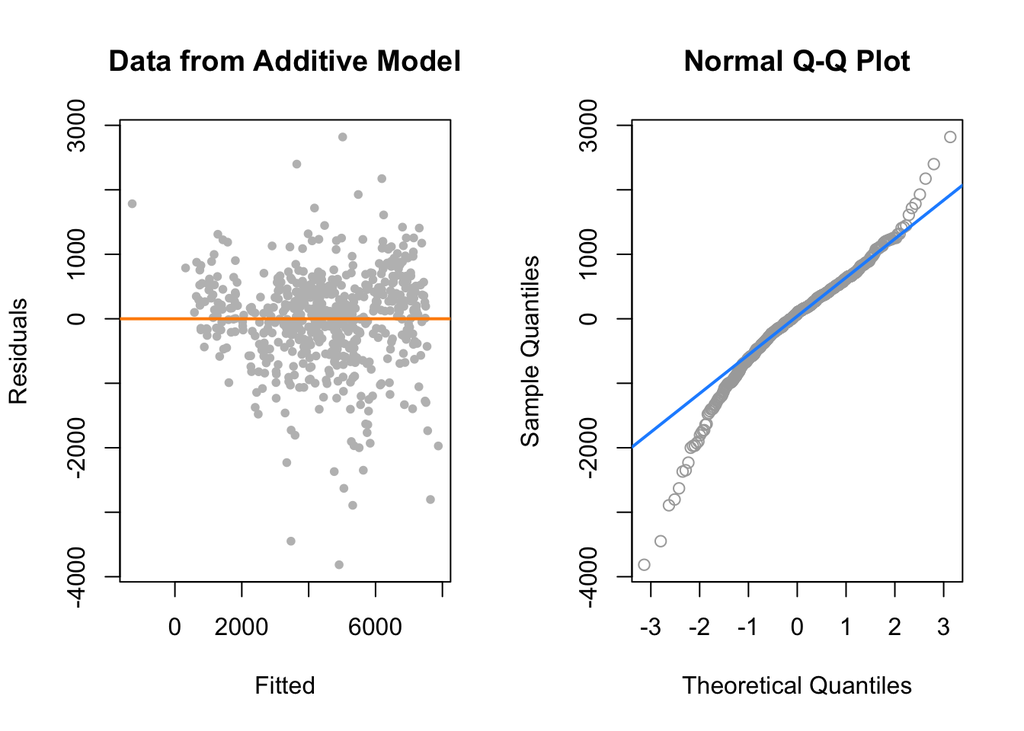

```r
plot_diagnostics(model1)
```

#### Model 2: Transformation

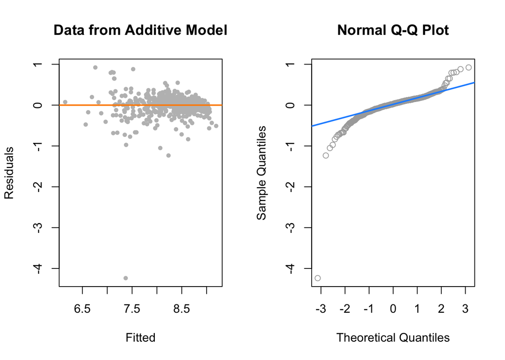

```r
plot_diagnostics(model2)
```

#### Model 3: Correlation Matrix

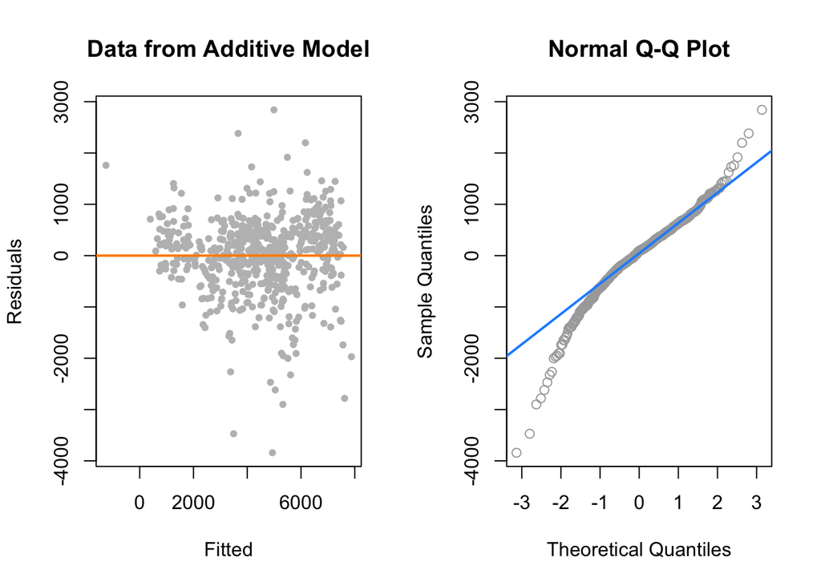

```r
plot_diagnostics(model3)
```

```r
vif_values_model_3 <- car::vif(model3)
vif_values_model_3
```

```
##                   temp                    hum              windspeed
##               6.903670               2.137385               1.235530
##          season_Summer            season_Fall          season_Winter
##               7.137282              11.250286               8.030649
##              year_2012         month_February            month_March
##               1.051248               1.823366               2.677195
##            month_April              month_May             month_June
##               5.111427               6.605775               6.630167
##             month_July           month_August        month_September
##               9.633546               9.470040               7.179579
##          month_October         month_November         month_December
##               5.848641               5.187972               3.310342
##            holiday_Yes         weekday_Monday        weekday_Tuesday
##               1.148598               1.820664               1.770195
##      weekday_Wednesday       weekday_Thursday         weekday_Friday
##               1.788651               1.775798               1.768503
##       weekday_Saturday       weathersit_Misty `weathersit_Snow/Rain`
##               1.776376               1.678435               1.350215
```

```r
#There are some variables with high VIP.
#Trying transformation here too to see if it reduces the VIF
```

#### Model 4: KNN Cross-Validation

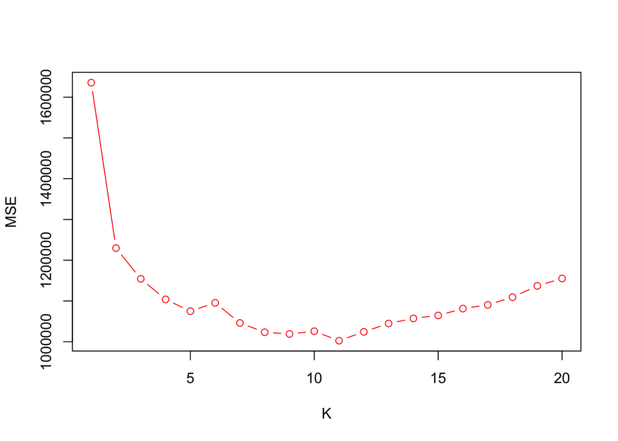

```r
# randomly shuffle the index
index.random <- sample(1:dim(bike_sharing_trn)[1])

# split the data (index) into 5 folds
groups <- cut(1:dim(bike_sharing_trn)[1], 5, labels = FALSE)
index.fold <- split(index.random, groups)

MSEs.k <- c()
for(k in 1:20){
  # an empty vector to save individual MSE
  MSEs <- c()

  # 5-fold cross-validation
  for(index.test in index.fold){

    # creat training and test set
    data.test <- bike_sharing_trn[index.test,]
    data.train <- bike_sharing_trn[-index.test,]

    # knn model
    knnmodel <- knnreg(data.train[,factors], data.train$cnt, k = k)

    # predict on the test set
    yhat.test = predict(knnmodel, data.test[,factors])


    # calculate test MSE
    y.test <- data.test$cnt
    MSE.test <- mean((y.test - yhat.test)^2)
    MSEs <- c(MSEs, MSE.test)
  }

  # Average 5 MSEs
  MSEs.k <- c(MSEs.k, mean(MSEs))
}

plot(MSEs.k, type='b', col='red', xlab='K', ylab='MSE',)
```

### NMSE Comparison

```r
library(knitr)

mod_list = list(model0, model1, model2, model3)
trn_nrmse = c(
  get_nrmse(model0, bike_sharing_trn),
  get_nrmse(model1, bike_sharing_trn),
  get_nrmse(model2, bike_sharing_trn_transformed),
  get_nrmse(model3, bike_sharing_trn_corr),
  NRMSE.train,
  NA,
  NA
)
tst_nrmse = c(
  get_nrmse(model0, bike_sharing_tst),
  get_nrmse(model1, bike_sharing_tst),
  NRMSE.t,
  get_nrmse(model3, bike_sharing_tst_corr),
  NRMSE.test,
  NRMSE.ridge,
  NRMSE.trr
)

nrsme_table = data.frame(
  c("Base Model", "AIC Model", "Transformation Model", "Correlation Model", 'KNN Model', 'Ridge Regression', 'Transform + RR'), trn_nrmse, tst_nrmse)

kable(nrsme_table, format = "markdown", col.names = c("Model", "Training NRMSE", "Testing NRMSE"))
```

| Model | Training NRMSE | Testing NRMSE |
| --- | --- | --- |
| Base Model | 0.1639217 | 0.1861117 |
| AIC Model | 0.1642360 | 0.1876196 |
| Transformation Model | 1.0836608 | 0.0319169 |
| Correlation Model | 0.1640145 | 0.1866556 |
| KNN Model | 0.1992266 | 0.2241404 |
| Ridge Regression | NA | 0.1923851 |
| Transform + RR | NA | 0.0350226 |

### R-Squared and VIF Test

```r
# TODO Add ANOVA Scores
F_scores <- c()
for (i in mod_list) {
  if (length(F_scores) == 0){
    F_scores <- append(F_scores, NA)
    next
  }
  F_scores <- append(F_scores, get_F_score(model0, i))
}
rvif_table = data.frame(
  c("Base Model", "AIC Model", "Transformation Model", "Correlation Model"), sapply(mod_list, get_r_squared), sapply(mod_list, get_max_vif), F_scores)

kable(rvif_table, format = "markdown", col.names = c("Model", "Adjusted R-Squared", "Max VIF", 'F-score'))
```

| Model | Adjusted R-Squared | Max VIF | F-score |
| --- | --- | --- | --- |
| Base Model | 0.8414820 | 70.18607 | NA |
| AIC Model | 0.8422943 | 6.07074 | 0.4261423 |
| Transformation Model | 0.7509001 | 11.19322 | 21.1412523 |
| Correlation Model | 0.8415880 | 11.25029 | 0.6284737 |

## Discussion

### Plot Diagnostics

Although this study intended to fit a good predictive model, the group members decided that all models must hold for all LINE assumptions, for them to be considered. Looking at the plot diagnostics, we notice the following:

`Model 1`’s Q-Q Plot had an evident tail on the left hand side, which resulted in a violation of the normality assumption. There is not much difference between this plot and the base model’s plot